# Input Uncertainty in Simulation Analytics

## Introduction

- Repeat exact same experiment, using different sample size of input data.

## Estimated Parameters

- Estimate input parameters using maximum likelihood estimation on 10^{4} observations each.
- Total of 7713 observations, approximately 16.5% above threshold.

### Baseline Model

- Create a baseline model that classifies all results as 1 and measure the F1 score.

```
## Baseline F1 score: 0.2828
```

### Logistic Regression Model

- Test the performance of a logistic regression model across the whole dataset.
- We use cross-validation with 5-folds.
- Note we shuffle the data as the ordering is not arbitrary.

```
## 0.8323 F1 score with a standard deviation of 0.004
```

- Logistic regression clearly outperforms the baseline model.
- We fit a logistic regression model to the whole dataset to produce our final predictive model.

## Performance at True Parameters

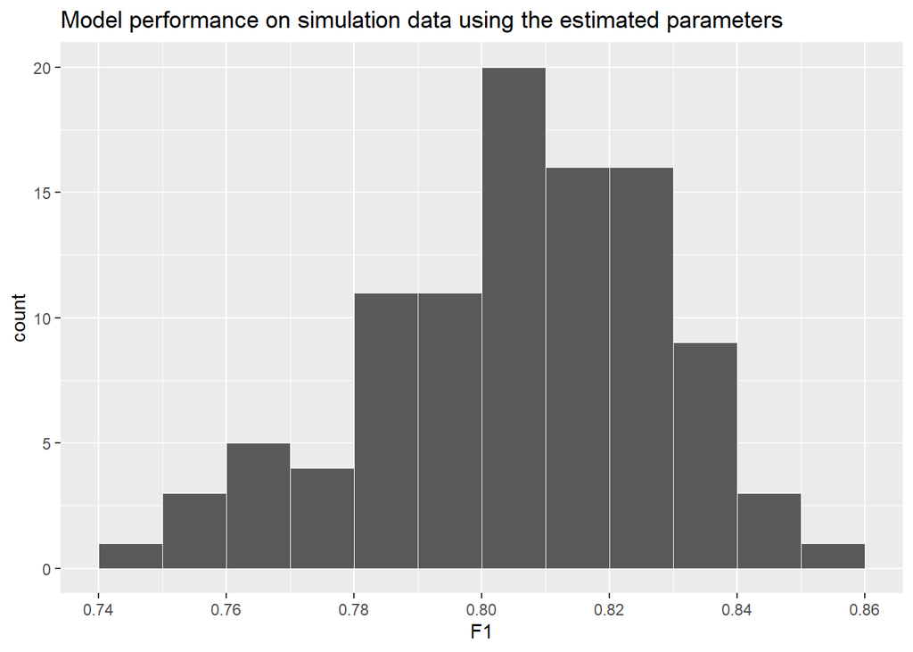

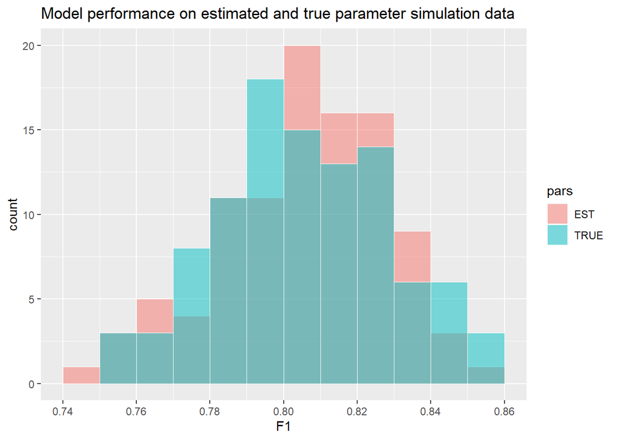

### Hypothesis Test

```
##
##  Two-sample z-Test
##
## data:  MLE_f1s$F1 and true_f1s$F1
## z = 0.015833, p-value = 0.9874
## alternative hypothesis: true difference in means is not equal to 0
## 95 percent confidence interval:
##  -0.006260403  0.006362375
## sample estimates:
## mean of x mean of y
## 0.8056505 0.8055995
```

- Large p-value suggests there is no significant difference in performance.

## Experimental Design

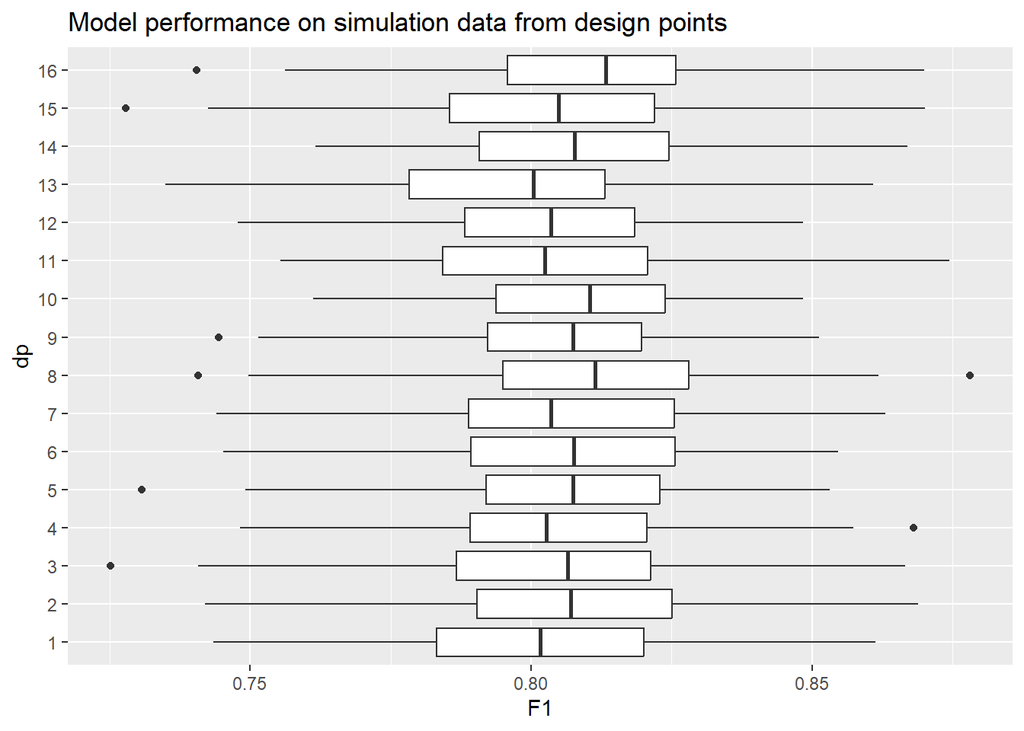

- Looks like much less variability in F1 scores compared to the previous case using smaller samples of input data.

```
##       lambda   mu1   mu2   mu3 mean_F1 sd_F1 p-value
##  [1,]   3.94 5.856 8.008 5.978   0.802 0.028   0.315
##  [2,]   4.02 5.856 8.008 5.978   0.807 0.026   0.786
##  [3,]   3.94 5.974 8.008 5.978   0.804 0.026   0.707
##  [4,]   4.02 5.974 8.008 5.978   0.805 0.024   0.732
##  [5,]   3.94 5.856 8.170 5.978   0.805 0.023   0.858
##  [6,]   4.02 5.856 8.170 5.978   0.808 0.023   0.449
##  [7,]   3.94 5.974 8.170 5.978   0.807 0.025   0.772
##  [8,]   4.02 5.974 8.170 5.978   0.811 0.026   0.143
##  [9,]   3.94 5.856 8.008 6.099   0.805 0.022   0.745
## [10,]   4.02 5.856 8.008 6.099   0.807 0.022   0.573
## [11,]   3.94 5.974 8.008 6.099   0.803 0.023   0.465
## [12,]   4.02 5.974 8.008 6.099   0.803 0.023   0.493
## [13,]   3.94 5.856 8.170 6.099   0.798 0.025   0.032
## [14,]   4.02 5.856 8.170 6.099   0.809 0.023   0.375
## [15,]   3.94 5.974 8.170 6.099   0.804 0.026   0.667
## [16,]   4.02 5.974 8.170 6.099   0.810 0.024   0.155
```

- Most design points have large p-values, indicating no significant change in performance.
- Only one design point with p-value < 0.05.

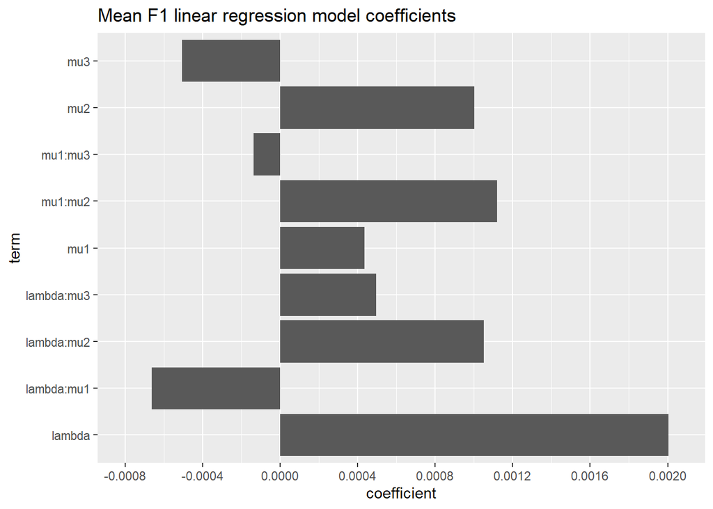

### Comparison to Mean Output

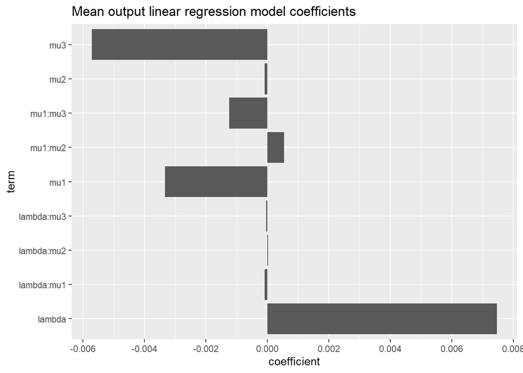

- Model has an R-squared score of 0.989.
- Similar results to last time, lambda largest magnitude, followed by mu3 then mu1.
- Direction and magnitude of coefficients do not align with mean F1 regression model, parameter values have different impact on performance of predictive model compared to impact on mean simulation output.